# Basic Data Cleaning and Vizualizations

Rage Against The Machine Learning

26/01/2021

# Basic Data Cleaning and Vizualization

We clean the data and do some basic data vizualization to get a feel for how the covariates affect one another.

## Importing and inspecting the data

```r
# Importing data from Eggafoss
eggafoss <- readRDS("~/water-shrinkage/raw_data_eggafoss.rds")
```

We begin by gauging basic information about the data:

```r
summary(eggafoss)
```

```
##       dato                nedbør      snødekningsgrad  snøvannekvivalent
##  Min.   :1941-04-01   Min.   :0.000   Min.   :  0.00   Min.   :0.000
##  1st Qu.:1960-12-07   1st Qu.:0.000   1st Qu.:  0.10   1st Qu.:0.000
##  Median :1980-08-15   Median :0.001   Median : 99.90   Median :0.093
##  Mean   :1980-08-15   Mean   :0.003   Mean   : 61.83   Mean   :0.175
##  3rd Qu.:2000-04-23   3rd Qu.:0.004   3rd Qu.:100.00   3rd Qu.:0.317
##  Max.   :2019-12-31   Max.   :0.090   Max.   :100.00   Max.   :0.994
##                       NA's   :6119    NA's   :6119     NA's   :6119
##    temperatur            VF               VST             MVF
##  Min.   :-39.500   Min.   :  0.443   Min.   :0.000   Min.   :  0.000
##  1st Qu.: -5.320   1st Qu.:  2.731   1st Qu.:1.440   1st Qu.:  1.383
##  Median :  0.490   Median :  6.665   Median :1.700   Median :  8.661
##  Mean   :  0.211   Mean   : 17.731   Mean   :1.826   Mean   : 18.622
##  3rd Qu.:  6.730   3rd Qu.: 19.089   3rd Qu.:2.110   3rd Qu.: 19.771
##  Max.   : 21.070   Max.   :394.590   Max.   :3.930   Max.   :248.964
##  NA's   :6119      NA's   :4                         NA's   :6119
```

```r
str(eggafoss)
```

```
## Classes 'data.table' and 'data.frame':   28764 obs. of  8 variables:
##  $ dato             : Date, format: "1941-04-01" "1941-04-02" ...
##  $ nedbør           : num  NA NA NA NA NA NA NA NA NA NA ...
##  $ snødekningsgrad  : num  NA NA NA NA NA NA NA NA NA NA ...
##  $ snøvannekvivalent: num  NA NA NA NA NA NA NA NA NA NA ...
##  $ temperatur       : num  NA NA NA NA NA NA NA NA NA NA ...
##  $ VF               : num  NA NA NA NA 1.37 ...
##  $ VST              : num  0 0 0 0 1.28 1.27 1.27 1.27 1.3 1.35 ...
##  $ MVF              : num  NA NA NA NA NA NA NA NA NA NA ...
##  - attr(*, ".internal.selfref")=<externalptr>
##  - attr(*, "sorted")= chr "dato"
```

Notice that **snødekningsgrad** is given in percent, so its range is between 0 and 100. The **dato** column shows that the collection of the data started in 1941 and goes all the up to the end of 2019.

## Missing Data Cleaning

We see from above that we are missing a lot of data from the columns **nedbør, snødekningsgrad, snøvannekvivalent, temperatur,** and **MVF**. To view the missing data visually, we use the package **naniar**:

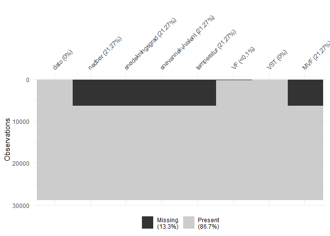

```r
library(naniar)
vis_miss(eggafoss)
```

It seems like all the missing data is from the first 6119 rows. This can be verified by the command:

```r
any(is.na(eggafoss[6120:28764, ]))
```

```
## [1] FALSE
```

For the first 6119 rows, we are missing so much data that the best option is to remove the first 6119 rows. This corresponds to data before 1958.

```r
eggafoss_from_1958 <- eggafoss[6120:28764, ]
head(eggafoss_from_1958)
```

```
##            dato nedbør snødekningsgrad snøvannekvivalent temperatur    VF  VST
## 6120 1958-01-01  0.000             100             0.252     -21.25 2.765 1.44
## 6121 1958-01-02  0.000             100             0.252     -30.54 2.575 1.43
## 6122 1958-01-03  0.003             100             0.256     -27.34 2.473 1.41
## 6123 1958-01-04  0.000             100             0.256     -29.02 2.416 1.41
## 6124 1958-01-05  0.000             100             0.256     -22.90 2.387 1.41
## 6125 1958-01-06  0.000             100             0.256     -10.44 2.359 1.40
##        MVF
## 6120 1.292
## 6121 1.187
## 6122 1.088
## 6123 0.998
## 6124 0.915
## 6125 0.839
```

Finally, let us rename the columns so that we avoid abbreviations:

```r
names(eggafoss_from_1958)[6:8] <- c("vannføring", "vannstand", "modellertvannføring")
names(eggafoss_from_1958)
```

```
## [1] "dato"                "nedbør"              "snødekningsgrad"
## [4] "snøvannekvivalent"   "temperatur"          "vannføring"
## [7] "vannstand"           "modellertvannføring"
```

## Basic Vizualizations

### Correlation Plot

```r
correlation_matrix <- cor(eggafoss_from_1958[, 2:8])
print(correlation_matrix)
```

```
##                          nedbør snødekningsgrad snøvannekvivalent  temperatur
## nedbør               1.00000000     -0.01545064       -0.02701560  0.02389686
## snødekningsgrad     -0.01545064      1.00000000        0.68660519 -0.72890246
## snøvannekvivalent   -0.02701560      0.68660519        1.00000000 -0.42506876
## temperatur           0.02389686     -0.72890246       -0.42506876  1.00000000
## vannføring           0.11122374     -0.11230711       -0.02222714  0.39788174
## vannstand            0.12393242     -0.33214848       -0.17916785  0.56950850
## modellertvannføring  0.09540356     -0.14642237       -0.07032235  0.44068166
##                      vannføring  vannstand modellertvannføring
## nedbør               0.11122374  0.1239324          0.09540356
## snødekningsgrad     -0.11230711 -0.3321485         -0.14642237
## snøvannekvivalent   -0.02222714 -0.1791678         -0.07032235
## temperatur           0.39788174  0.5695085          0.44068166
## vannføring           1.00000000  0.8808608          0.90994206
## vannstand            0.88086082  1.0000000          0.83777508
## modellertvannføring  0.90994206  0.8377751          1.00000000
```

To get a visual look at the correlation matrix, we use the packages **reshape2** and **ggplot2**:

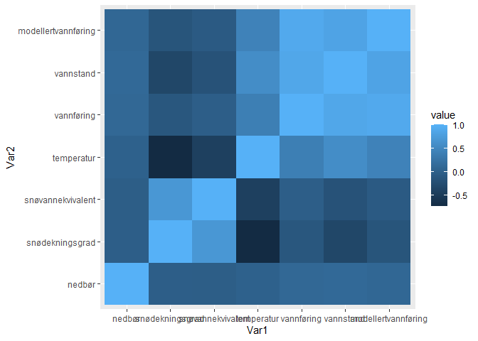

```r
library(reshape2)
library(ggplot2)

ggplot(data = melt(correlation_matrix), aes(x = Var1, y = Var2, fill = value)) +
  geom_tile()
```

### Scatterplot

To avoid to many points at once, we sample 2000 points from our data so that the underlying structure of the data becomes clearer:

```r
eggafoss_sample <- eggafoss_from_1958[sample(nrow(eggafoss_from_1958), 2000), ]
```

We now some basic scatterplots with **ggplot2**:

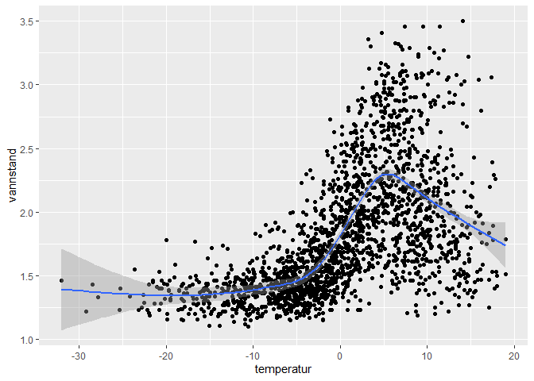

```r
library(ggplot2)
ggplot(data = eggafoss_sample, aes(x = temperatur, y = vannstand)) + geom_point() +
  geom_smooth()
```

Here we see that there is a positive trend, that is most clear in the temperature interval between -10 and 5. This can indicate that **vannstand** is seasonal-dependend, and that a high **vannstand** occurs in the spring.

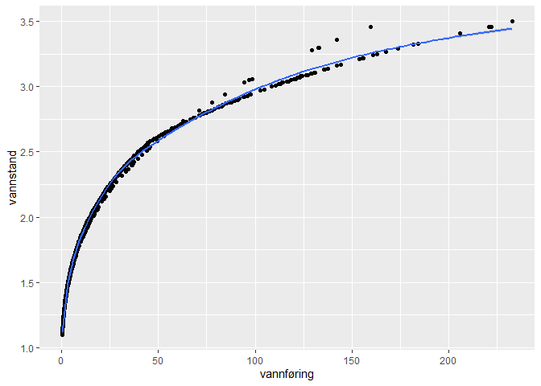

```r
library(ggplot2)
ggplot(data = eggafoss_sample, aes(x = vannføring, y = vannstand)) + geom_point() +
  geom_smooth()
```

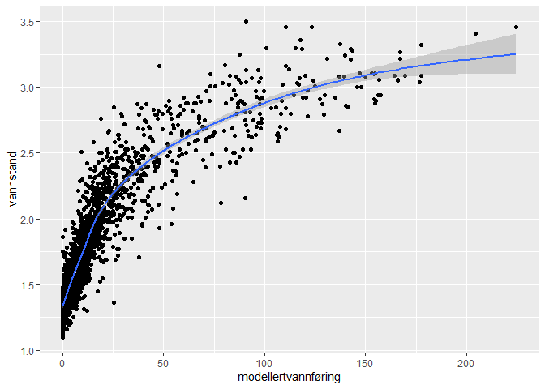

```r
library(ggplot2)
ggplot(data = eggafoss_sample, aes(x = modellertvannføring, y = vannstand)) + geom_point() +
  geom_smooth()
```